# Support Vector Machines

Roger Bukuru

2024-06-05

# Introduction

- Support vector machines (SVMs) are a group of supervised machine-learning models that can be used for classification and regression. SVMs are among the most popular standard tools for classification.
  - SVMs seek an optimal hyperplane for separating two classes in a multidimensional space
  - For two variables (features, independent variables), the surface is a line $w_1x_1+w_2x_2+b=0$
  - For three variables (features, independent variables), the surface is a plane $w_1x_1+w_2x_2+w_3x_3+b=0$

## Maximal Margin Classifier

- We start by using 1 independent variable and binary classification $y\in\{1,-1\}$

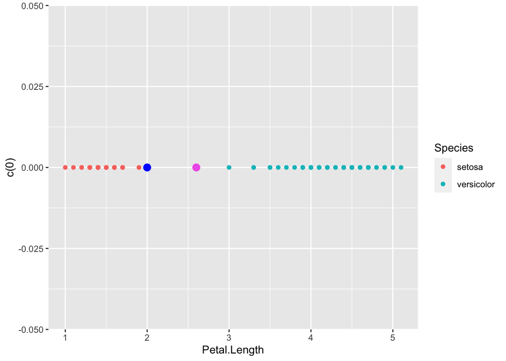

```r
rm(list = ls())
library(ggplot2)

data("iris")
p1 = ggplot(data = iris[1:100,],aes(x = Petal.Length, y = c(0)))+
            geom_point(aes(color = Species))

boundaries = data.frame(seperator = c(2,2.6))

p1+geom_point(data = boundaries, aes(x=boundaries$seperator[1]), color = "blue", size =3)+
  geom_point(data=boundaries, aes(x=boundaries$seperator[2]), color = "#F066EA", size = 3)
```

```r
#p2 = ggplot(data=iris[1:100,], aes(x=Petal.Width, y=Petal.Length))+
           geom_point(aes(color=Species))
```

```
## mapping: colour = ~Species
## geom_point: na.rm = FALSE
## stat_identity: na.rm = FALSE
## position_identity
```

```r
#p2
```

Let’s now look at a 2D example

- We will now use the $Petal.Length$ and $Petal.Width$ variables(x) to classify the flower $Species(y)$ for the first 100 observations so that the problem is a binary classification. Let us visualize our data.

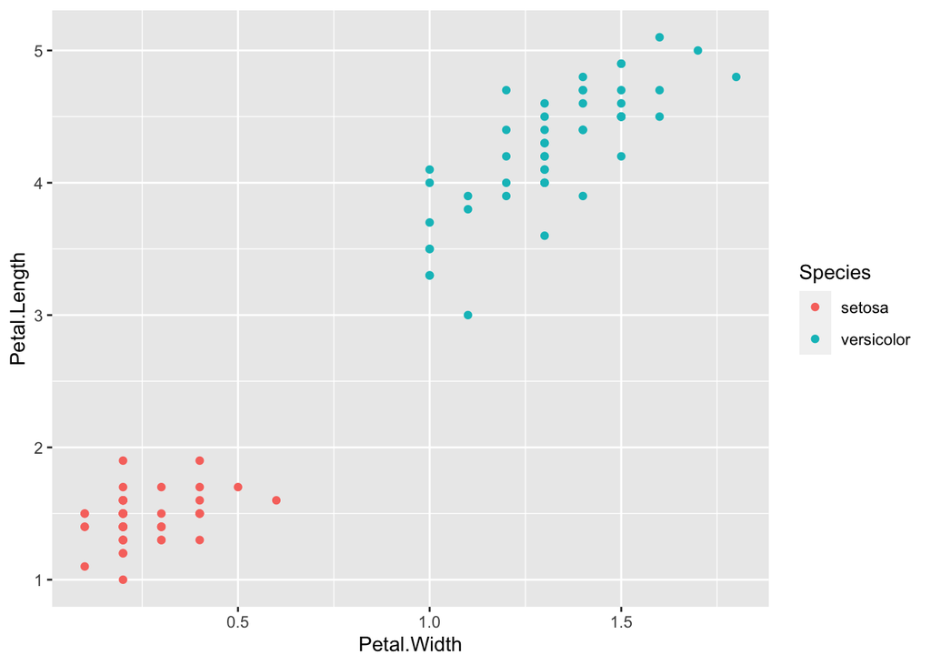

```r
rm(list = ls())
library(ggplot2)

data("iris")
p2 = ggplot(data = iris[1:100,], aes(x=Petal.Width, y=Petal.Length))+
     geom_point(aes(color= Species))
p2
```

- There are infinite number of lines that separate the group of points $x_i$ for which $y_i = -1$ from the points for which $y_i = +1$
- Which one is the best ?

Maximal Margin Classifier - Which Line ?

- Suppose that is possible to construct a line that separates the training observations perfectly according to their class labels.
- Then the separating line has the property that
- $b + w_{1}x_{i1} +. w_{2}x_{i2} > 0 if y_i = +1$
- $b + w_{1}x_{i1} +. w_{2}x_{i2} < 0 if y_i = -1$

- NB: Line is defined with the folowing:
  - $b+w_1x_{i1} + w_2x_{i2} = 0$
  - $w^Tx+b=0$ (here $w$ is always normal to the hyperplane)
  - If $b=0$ then the line goes through the origin
  - But how do we find the values of $b,w_1,w_2$

## Construction of the maximal margin

- We start by constructing the the boundary lines that separates the $+1$ and $-1$ points these are known as the support vector lines $H_1$ and $H_2$
- Then we find the closest points in Convex Hulls
- Points that touch the boundary lines are the support vectors
- We then construct the soft marginal line $b+w_1x_{i1} + w_2x_{i2} = 0$
- Data closes to the hyperplane are called support vectors
- The plane $H_0$ is the median in between the support vectors $H_1$ and $H_2$ and it is called the Maximal Margin Classifier with $b+w_1x_{i1}+w_2x_{i2} = 0$
- The “Margin” is the distance between $H_1$ and $H_2$ and it is calculated as follows: $2M=\frac{2}{||w||}$
- We want to find the “maximum-margin hyperplane” that divides the groups, so that the distance $2M$ between the two hyperplanes $H_1$ and $H_2$ is maximized
- Optimization problem!
- Maximal margin hyperplane is extremely sensitive to a change in a single observation: Overfit.

## Soft Margin Classifier

- In this case, we might be willing to consider a classifier based on a hyperplane that does not perfectly separate the two classes, in the interest of:
  - Greater robustness to individual observations
  - Better classification of most of the training observations
- That is, it could be worthwhile to misclassify a few training observations in order to do a better job in classifying the remaining observations
- The support vector classifier, sometimes called a soft-margin classifier, exactly does this.
- Slack variables $\zeta_i$ can be added to allow misclassification of difficult or noisy examples
- Slack variables $\zeta_i$ = support vectors
  - Slacks variables defined as $\zeta = (\zeta_1, \zeta_2,...\zeta_n)\ge0$
  - Data points are correctly classified, for $\zeta_i=0$ and the data points are either on the margin (SV) or on the correct side of the margin
  - Our goal is now to maximize the margin while softly penalizing points that lie on the wrong side of the margin boundary: Use of $C$ cost

## Support Vectors

- Observations that lie directly on the margin, or on the wrong side of the margin for their class, are known as support vectors
- Support vectors do affect the support vector classifier. Others that are on the correct side of the margin do no affect the SVC
- A direct implication is that the more the support vectors, the better the generalizability of the boundary
- The number of support vectors is controlled by $V$
- When $V$ is large, then the margin is wide, many observations violate the margin, and so there are many support vectors. In this case, many observations are involved in determining the hyperplane.

**Construction of the Soft Margin**

- The margin $2M$ is maximized subject to a toal budget of $\sum\zeta_{i}^*\le V$, where $V$ is the total number of violations and $\sum\zeta_{i}^*$ is the total distance of points on the wrong side of their margin.
- V is the amount that the margin can be violated by the $n$ observations
- If $V=0$, no budget for violations $\zeta=(\zeta_1, \zeta_2,...\zeta_n) = 0$ and this is simply the maximal margin hyperplane optimization (assuming a perfect plane exists)
- If $V>0$, no more than $V$ observations can be on the wrong side of the hyperplane, because if an observation is on the wrong side of the hyperplane, then $\zeta_i>1$
- As V increases, we are more tolerant of violations to the margin, hence wider margin
- As V decreases, we are less tolerant, hence narrower margin
- In practice, we choose $V$ via cross-validaton
- Counting support vectors ??
- Cost vs the errors
  - The higher the cost is, the number of support vectors allowed is fewer. More precise estimates. Therefore low bias, however overfitting which means high variance. Low cost means less strict predictiom resulting in higher bias. We examine the lowest error for the validation set.

### Examples

```r
rm(list = ls())
library(e1071)
library(ggplot2)
library(tidyverse)
library(dplyr)

#iris_data = data("iris")
iris_data = iris%>%
       as_tibble() %>%
       mutate(Species = as.factor(Species))


svm_model = svm(Species ~ Petal.Width + Petal.Length,
                data = iris_data[1:100,],
                type= "C-classification",
                kernel = "linear", # type of hyperplane
                scale = FALSE,
                cost =2,
                )

svm_model
```

```
##
## Call:
## svm(formula = Species ~ Petal.Width + Petal.Length, data = iris_data[1:100,
##     ], type = "C-classification", kernel = "linear", cost = 2, ,
##     scale = FALSE)
##
##
## Parameters:
##    SVM-Type:  C-classification
##  SVM-Kernel:  linear
##        cost:  2
##
## Number of Support Vectors:  2
```

```r
# Obtain the index of support vectors in dataset
svm_model$index
```

```
## [1] 45 99
```

```r
# Obtain the support vectors
svm_model$SV
```

```
##    Petal.Width Petal.Length
## 45         0.4          1.9
## 99         1.1          3.0
```

```r
#Obtain the intercept of the model
svm_model$rho
```

```
## [1] -3.788235
```

```r
#Weighting coefficients of the support vectors, the magnitude represents the importance of the SV and the sign represents which side of the boundary the vectors are.
svm_model$coefs
```

```
##          [,1]
## [1,]  1.17647
## [2,] -1.17647
```

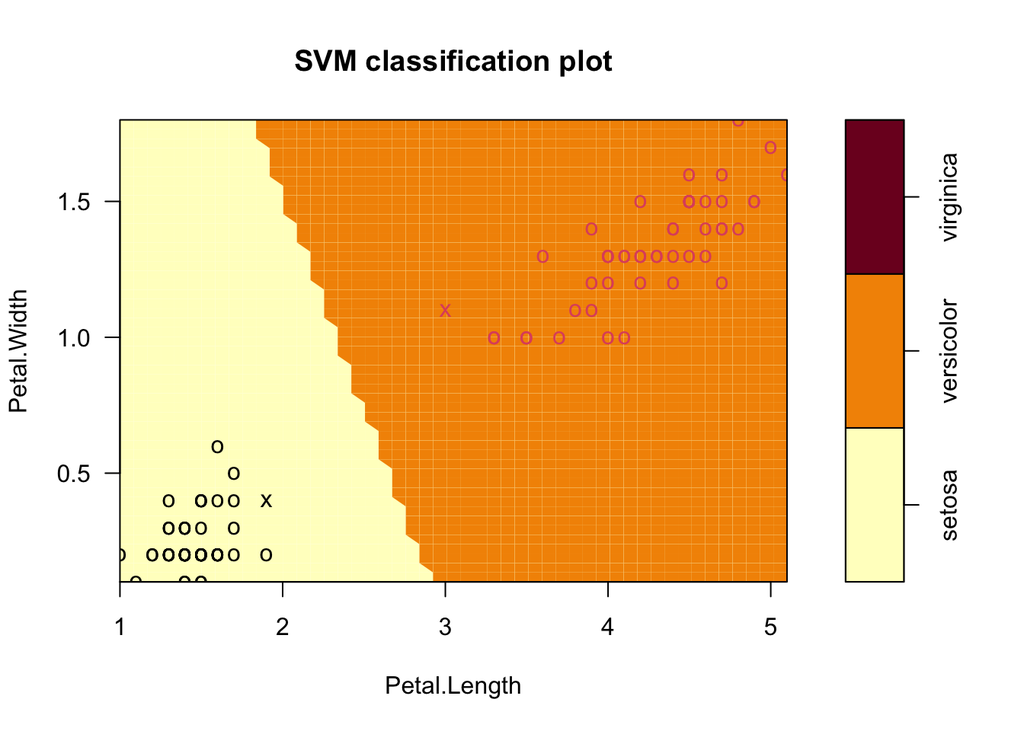

```r
plot(svm_model, iris_data[1:100, c(3:4,5)])
```

- It is clear that there are 2 support vectors and these are marked with a $X$, however, this plot is less informative so let us do our own plot

#### Building a Support Vector Classifier in R: Maximal Margin

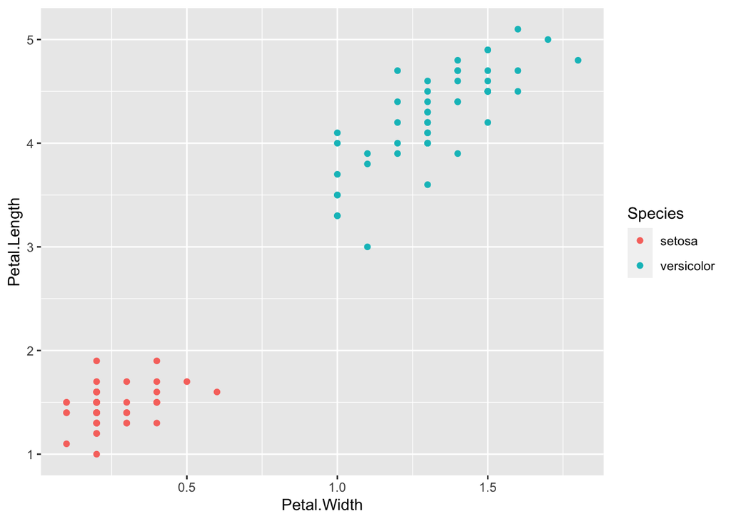

```r
rm(list = ls())
library(e1071)
library(ggplot2)
library(tidyverse)
library(dplyr)

iris_data = iris%>%
       as_tibble() %>%
       mutate(Species = as.factor(Species))

p2 <- ggplot(data=iris[1:100,], aes(x=Petal.Width, y =Petal.Length))+
  geom_point(aes(color = Species))
p2
```

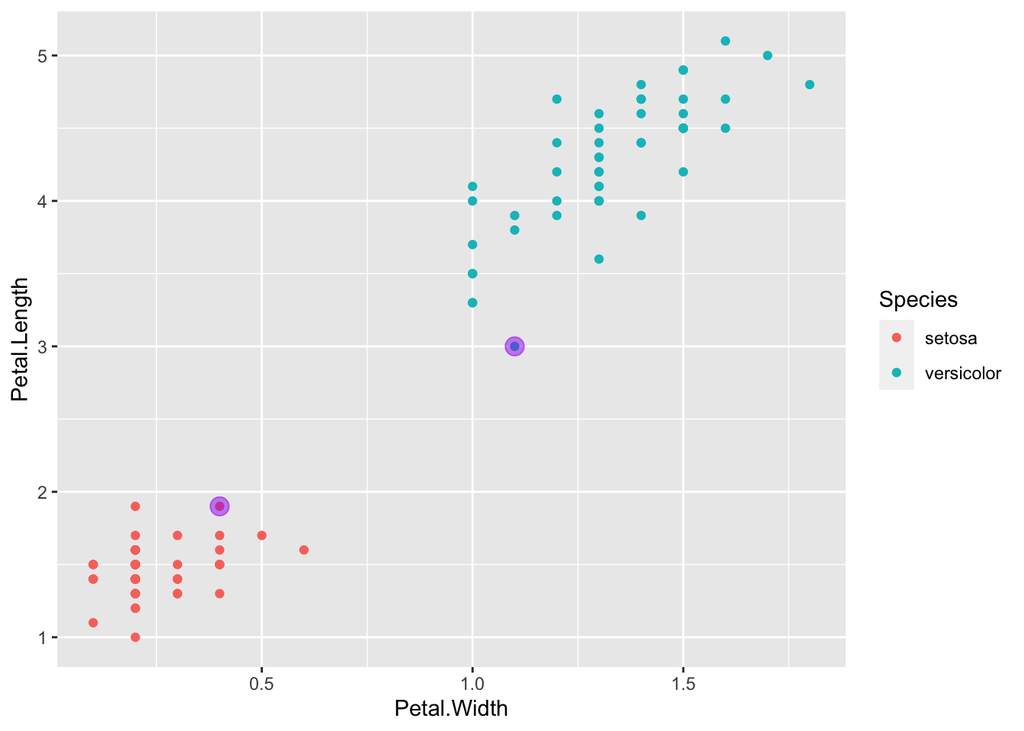

```r
svm_model = svm(Species ~ Petal.Width + Petal.Length,
                data = iris_data[1:100,],
                type= "C-classification",
                kernel = "linear", # type of hyperplane
                scale = FALSE,
                cost =2,
                )

#identify support vectors
df_sv <- iris[svm_model$index,]

# and mark the support vectors in the previous plot
p3 <- p2 + geom_point(data = df_sv, aes(x=Petal.Width, y=Petal.Length), color = "purple", size = 4, alpha = 0.5)
p3
```

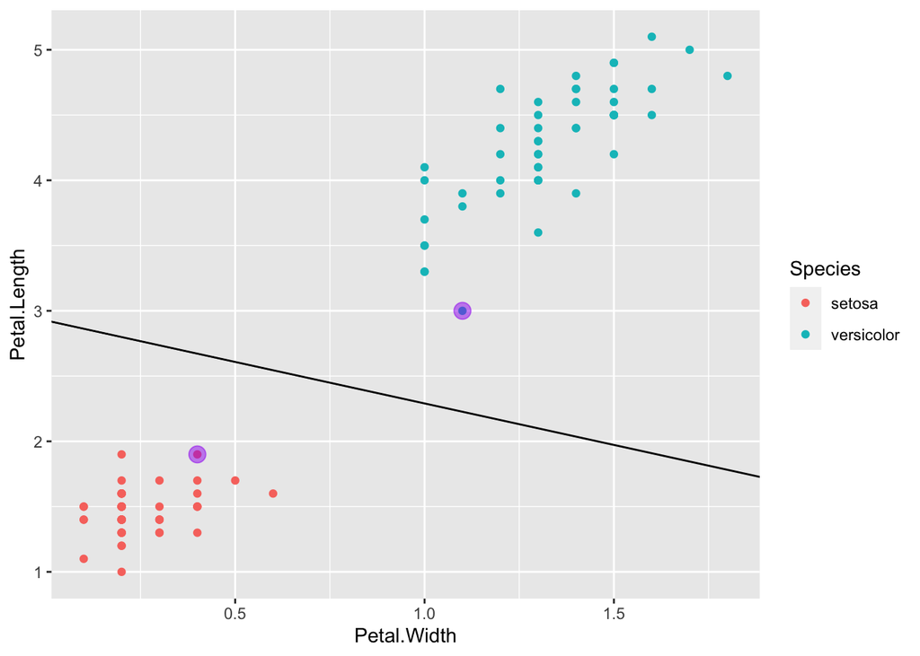

```r
#build weight vector
w <- t(svm_model$coefs) %*% svm_model$SV # ????????

#calculate slope and save it to a variable
slope_1 <- -w[1]/w[2]

# And finally we need to get the intercept value of the decision boundary, calculate intercept and save it to a variable
intercept_1 <- svm_model$rho/w[2]

# Add decision boundary with geom_abline() to the plot, using the slope and intercept calculated.

p3 <- p3 + geom_abline(slope = slope_1, intercept = intercept_1)

p3
```

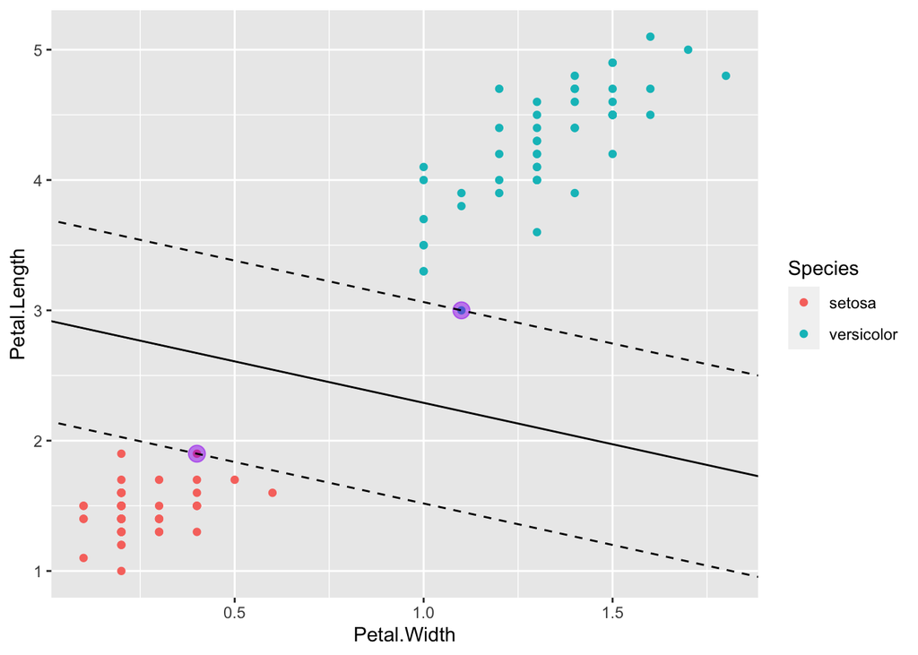

```r
#Margins parallel to decision boundary, offset by 1/w[2] on either side of it. So we can add them as well:
#add margins to plot

p3 <- p3 +
    geom_abline(slope = slope_1, intercept = intercept_1-1/w[2], linetype = "dashed") +
    geom_abline(slope = slope_1, intercept = intercept_1+1/w[2], linetype = "dashed")
#display plot

p3
```

```r
#training accuracy
#Obtain class predictions for training (and test) sets
# Evaluate the training (and test) set accuracy of the model
svm.pred <-predict(svm_model, iris[1:100,c(4,3)])
#compare the observed and predicted classes
mean(svm.pred==iris[1:100,c(5)])
```

```
## [1] 1
```

#### Building a Support Vector Classifier in R: Soft Margin

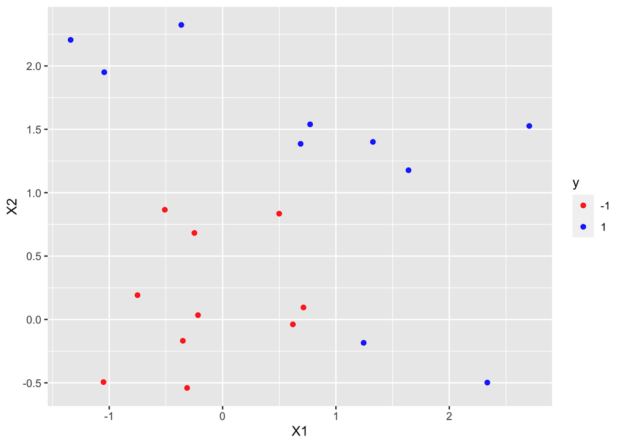

```r
rm(list = ls())
library(e1071)
library(ggplot2)
library(tidyverse)
library(dplyr)


load("linearInsep.RData")
p2_insep <- ggplot(data=dat, aes(x=X1, y =X2))+ geom_point(aes(color = y), alpha=.9) + scale_color_manual(values=c("red", "blue"))
p2_insep
```

```r
svm_model2_cost1 <- svm(y ~ X1 + X2,
                 data = dat,
                 type = 'C-classification',
                 kernel = "linear",
                 scale = FALSE,
                 cost=10) # gamma not applicable in linear
svm_model2_cost1
```

```
##
## Call:
## svm(formula = y ~ X1 + X2, data = dat, type = "C-classification",
##     kernel = "linear", cost = 10, scale = FALSE)
##
##
## Parameters:
##    SVM-Type:  C-classification
##  SVM-Kernel:  linear
##        cost:  10
##
## Number of Support Vectors:  6
```

```r
# Obtain the index of support vectors in dataset
svm_model2_cost1$index
```

```
## [1]  1  4 10 14 16 20
```

```r
#Obtain the intercept of the model
svm_model2_cost1$rho
```

```
## [1] -2.403917
```

```r
# Obtain the support vectors
svm_model2_cost1$SV
```

```
##            X1          X2
## 1   0.4992207  0.83459057
## 4   0.7136758  0.09454017
## 10 -0.2485535  0.68234694
## 14  2.3354574 -0.49779748
## 16  1.2445945 -0.18418390
## 20 -1.0440209  1.95016425
```

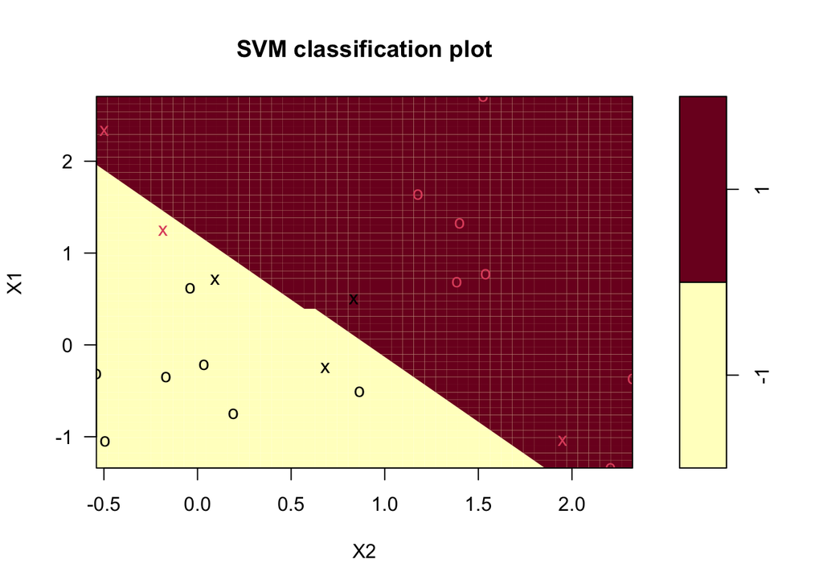

```r
plot(svm_model2_cost1, dat)
```

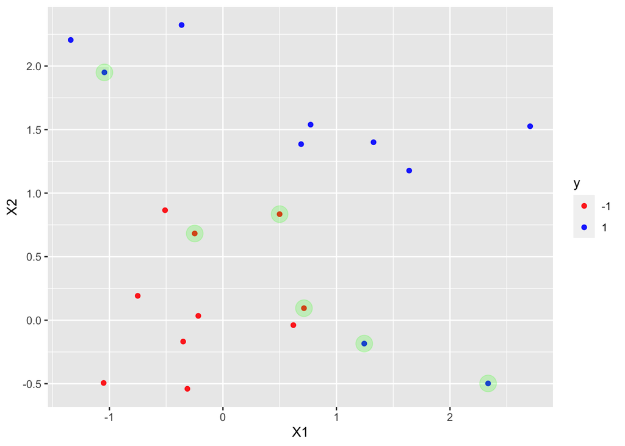

```r
#identify support vectors indices

df_sv2 <-dat[svm_model2_cost1$index,]

#mark out support vectors in plot
p3_insep <- p2_insep + geom_point(data = df_sv2[,c(1,2)], aes(x=X1, y=X2), color = "green", size = 6, alpha = 0.2)
p3_insep
```

- Now we need to add the decision boundary to the plot, we need the slope and intercept of the decision boundary. These are not stored anywhere, so we need to obtain the slope and intercept of the boundary.
- First step is to build the weight vector, w, from coefs and SV elements of svm_model.

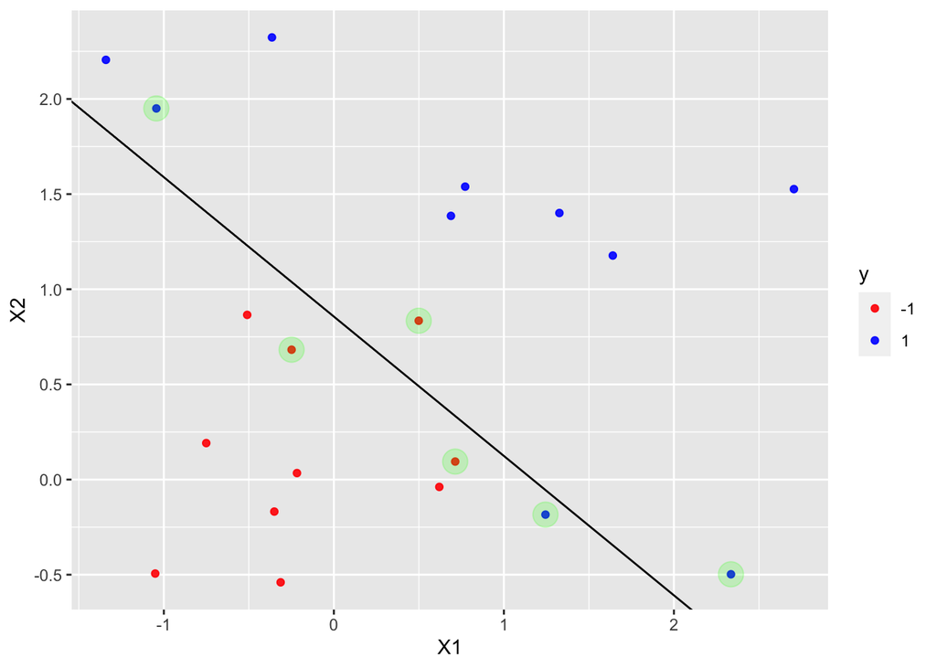

```r
#build weight vector

w2 <- t(svm_model2_cost1$coefs) %*% svm_model2_cost1$SV # this is a matrix multiplication
#calculate slope and save it to a variable
slope_2 <- -w2[1]/w2[2]

# And finally we need to get the intercept value of the decision boundary, calculate intercept and save it to a variable
intercept_2 <- svm_model2_cost1$rho/w2[2]

# Add decision boundary with geom_abline() to the plot, using the slope and intercept calculated.
p3_insep <- p3_insep + geom_abline(slope = slope_2, intercept = intercept_2)
p3_insep
```

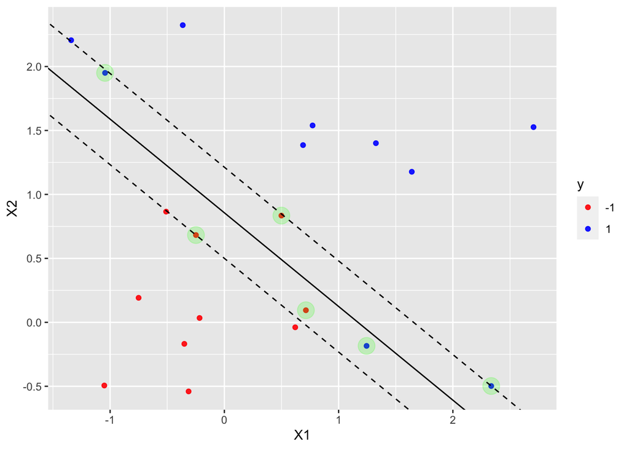

```r
#Margins parallel to decision boundary, offset by 1/w[2] on either side of it. So we can add them as well:
#add margins to plot
p3_insep <- p3_insep +
    geom_abline(slope = slope_2, intercept = intercept_2-1/w2[2], linetype = "dashed") +
    geom_abline(slope = slope_2, intercept = intercept_2+1/w2[2], linetype = "dashed")
#display plot
p3_insep
```

```r
#training accuracy
svm.pred2 <- predict(svm_model2_cost1, dat)
#compare the observed and predicted classes
mean(svm.pred2==dat$y)
```

```
## [1] 0.9
```

We now investigate different cost values and see what happens

- The cost parameter in svm() R function is the constant in the regularization term in the Lagrange multiplier.
- If you know that the decision boundary is linear, a narrow margin can be more useful.

**Tune you model**

- The authors of libsvm suggest to try small and large values for C—like 1 to 1000—first, then to decide which are better for the data by cross validation, and finally to try several γ’s (0.1, 0.01, 0.001, 0.0001, 0.00001) for the better C’s.
- However, better results are obtained by using a grid search over all parameters. For this, we recommend to use the tune.svm() function in e1071.

```r
# set a cost range, 10-fold cross validation
set.seed(1) # set a seed to get the same results with the slides
obj = tune.svm(as.factor(y) ~ X1 + X2, data = dat, type = "C-classification", cost=seq(from=0.005, to=10,by=0.005), gamma = 1) # gamma is the radial kernel parameter, # not applicable in linear
print(obj)
```

```
##
## Parameter tuning of 'svm':
##
## - sampling method: 10-fold cross validation
##
## - best parameters:
##  gamma cost
##      1 0.61
##
## - best performance: 0.05
```

```r
summary(obj)
```

```
##
## Parameter tuning of 'svm':
##
## - sampling method: 10-fold cross validation
##
## - best parameters:
##  gamma cost
##      1 0.61
##
## - best performance: 0.05
##
## - Detailed performance results:
##      gamma   cost error dispersion
## 1        1  0.005  0.45  0.4972145
## 2        1  0.010  0.45  0.4972145
```

[output cut: 1998 more lines]

```r
### Best model
bestmod = obj$best.model
bestmod
```

```
##
## Call:
## best.svm(x = as.factor(y) ~ X1 + X2, data = dat, gamma = 1, cost = seq(from = 0.005,
##     to = 10, by = 0.005), type = "C-classification")
##
##
## Parameters:
##    SVM-Type:  C-classification
##  SVM-Kernel:  radial
##        cost:  0.61
##
## Number of Support Vectors:  17
```

# Appendix

## LLM Finetuning

- Hyperparameter tuning of cost function

## Weight matrix

The weight vector ($w$) in the context of a Support Vector Machine (SVM) classifier, specifically for the maximal margin classifier (linear SVM), is a critical component that defines the orientation of the hyperplane separating the classes. Let’s break down its definition and the related code in your example:

### Definition of the Weight Vector

In a linear SVM, the goal is to find the hyperplane that best separates the classes by maximizing the margin between the closest points of each class (support vectors) and the hyperplane. The equation of the hyperplane in the feature space can be written as:

$$w^T x + b = 0$$

where: - $w$ is the weight vector, which is perpendicular to the hyperplane. - $x$ is a feature vector. - $b$ is the intercept (bias term).

### Calculation of the Weight Vector

The weight vector can be computed from the support vectors and their corresponding coefficients (Lagrange multipliers) obtained from solving the SVM optimization problem. The SVM model provides these coefficients as `svm_model$coefs` and the support vectors as `svm_model$SV`.

The weight vector $w$ is calculated as:

$$w = \sum_{i=1}^n \alpha_i y_i x_i$$

where: - $\alpha_i$ are the Lagrange multipliers (support vector coefficients). - $y_i$ are the class labels of the support vectors. - $x_i$ are the support vectors.

### Your Code for Weight Vector Calculation

In your code, the weight vector is computed as follows:

```r
# Build weight vector
w <- t(svm_model$coefs) %*% svm_model$SV
```

### Explanation of the Code

1. **Support Vectors and Coefficients**:
   - `svm_model$coefs` provides the coefficients (Lagrange multipliers) for the support vectors.
   - `svm_model$SV` provides the support vectors.
2. **Matrix Multiplication**:
   - `t(svm_model$coefs)` transposes the coefficients vector to align it properly for matrix multiplication.
   - `%*%` performs matrix multiplication between the transposed coefficients and the support vectors.

### Example Calculation

To understand the calculation, let’s assume the coefficients and support vectors are as follows (simplified example):

- Coefficients (`svm_model$coefs`): $\alpha = [0.5, 0.3, 0.2]$
- Support Vectors (`svm_model$SV`):
  $$\begin{bmatrix}
  1 & 2 \\
  2 & 3 \\
  3 & 4 \\
  \end{bmatrix}$$

Then, the weight vector $w$ is calculated as:

```r
w <- t(c(0.5, 0.3, 0.2)) %*% matrix(c(1, 2, 2, 3, 3, 4), nrow=3, byrow=TRUE)
```

### Intercept Calculation

The intercept ($b$) is calculated as:

```r
intercept_1 <- svm_model$rho / w[2]
```

### Visualization with `geom_abline`

To visualize the decision boundary and the margins, you add lines to the plot using `geom_abline()`:

- **Decision Boundary**:

  ```r
  p3 <- p3 + geom_abline(slope = slope_1, intercept = intercept_1)
  ```

- **Margins**:

  ```r
  p3 <- p3 +
      geom_abline(slope = slope_1, intercept = intercept_1 - 1 / w[2], linetype = "dashed") +
      geom_abline(slope = slope_1, intercept = intercept_1 + 1 / w[2], linetype = "dashed")
  ```

### Complete Process

1. **Load and Prepare Data**:
   - Load the `iris` dataset and preprocess it.
   - Visualize the initial data with `ggplot2`.
2. **Train the SVM Model**:
   - Train a linear SVM model on the `iris` dataset.
3. **Identify Support Vectors**:
   - Extract the support vectors and add them to the plot.
4. **Compute Weight Vector and Intercept**:
   - Calculate the weight vector and intercept to define the decision boundary.
5. **Plot Decision Boundary and Margins**:
   - Add the decision boundary and margins to the plot for visualization.
6. **Evaluate Model**:
   - Obtain class predictions and evaluate the model’s accuracy.

By following these steps, you can build and visualize an SVM maximal margin classifier in R.